# SUMMARY SESSION 6

Victor Miguel Terrón Macias

30/1/2021

# EJEMPLOS DE SERTIES DE TIEMPO Y TECNICAS DESCRIPTIVAS

Las series de tiempo son analizadas para entender el pasado y para predecir el futuro, permitiendo a los administradores o creadores de políticas tomar decisiones informadas propiamente.

Cuando una variable es medida secuencialmente en el tiempo durante o en un intervalo fijo, conocido como el intervalo de muestreo, los datos que resultan forman una serie de tiempo.

El número de reservas de pasajeros internacionales (en miles) por mes en una aerolínea (Pan Am) en los Estados Unidos fue obtenida de la Administración de Aviación Federal para el periodo 1949-1960 (Brown, 1963). La compañía usó los datos para predecir la demanda futura antes de ordenar nuevos aviones y tripulación de entrenamiento.

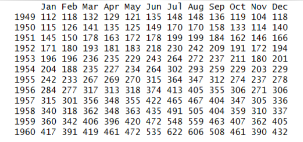

Imagen

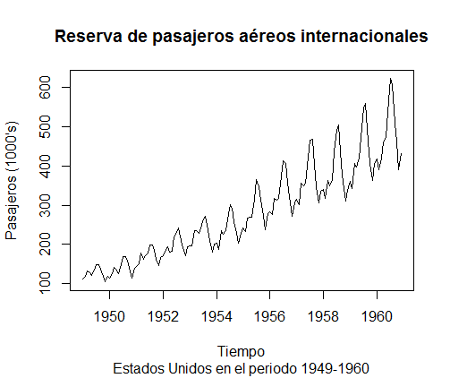

Imagen

Tendencia. - En general, un cambio sistemático en una serie de tiempo que no parece ser periódica es conocida como una tendencia.

Variación estacional. - Un patrón que se repite dentro de cada año es conocido como variación estacional, aunque el término es aplicado más generalmente para patrones que se repiten dentro de cualquier periodo fijo.

Ciclos. - A veces podemos afirmar que hay ciclos en una serie de tiempo que no corresponden a algún periodo natural fijo.

Los pronósticos confían en la extrapolación, y los pronósticos están generalmente basados en la suposición de que las tendencias presentes continuarán. No podemos verificar esta suposición en alguna forma empírica, pero si podemos identificar causas probables para una tendencia, podemos justificar extrapolarla, por algunos pocos pasos en el tiempo al menos.

Un pronóstico es un valor futuro que se predice, y el número de pasos de tiempo hacia el futuro es el tiempo de espera (k).

Hay varias formas para estimar la tendencia mt al tiempo t, pero un procedimiento relativamente simple, el cual está disponible en R y no asume ninguna forma específica es calcular un promedio móvil centrado en xt.

La longitud de pronósticos promedio móvil es elegida para promediar los efectos estacionales, los cuales pueden ser estimados después.

Un segundo algoritmo de suavizamiento ofrecido por R es stl. Este usa una técnica de regresión ponderada localmente conocida como loess.

Procedimientos de suavizamiento tales como el promedio móvil centrado y loess no requieren un modelo predeterminado, pero no producen una fórmula que pueda ser extrapolada para dar pronósticos

En R, la función decompose estima tendencias y efectos estacionales usando un método de promedio móvil.

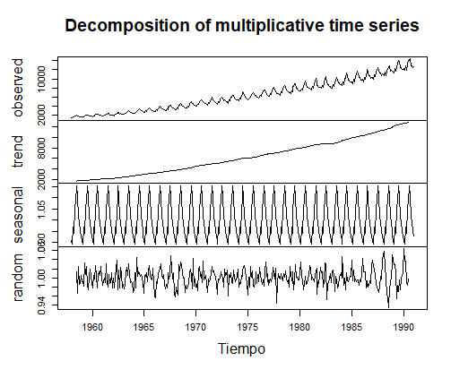

Imagen

## MODELOS ESTADÍSTICOS BÁSICOS, MODELOS ESTACIONARIOS Y PREDICCIÓN

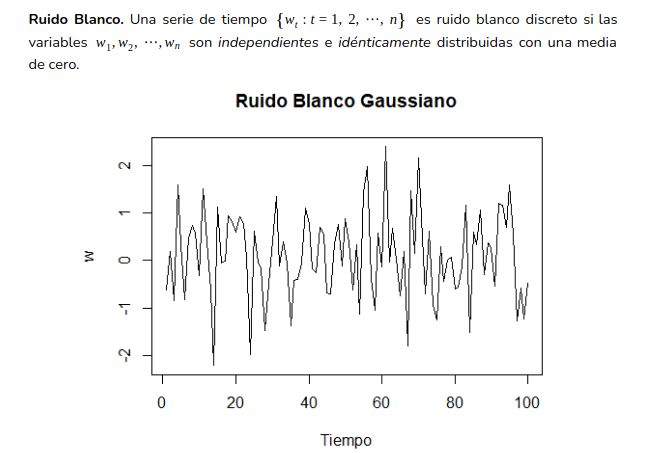

Imagen

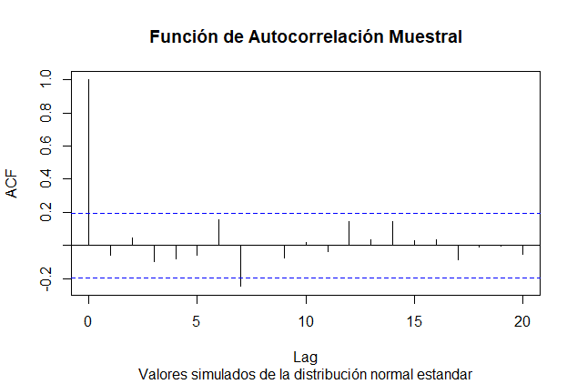

Imagen

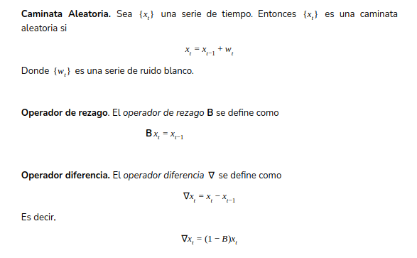

Imagen

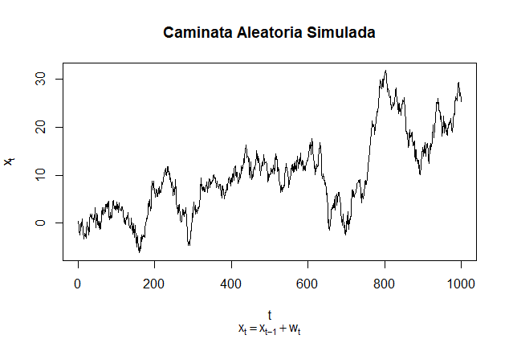

Imagen

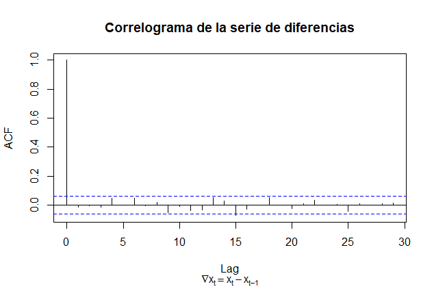

Imagen

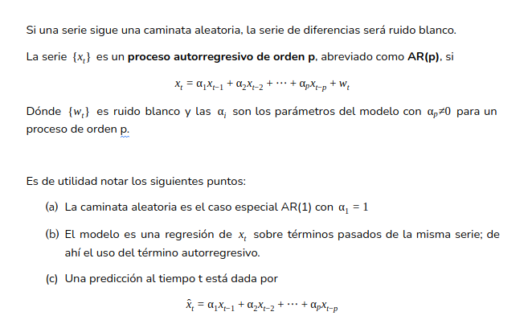

Imagen

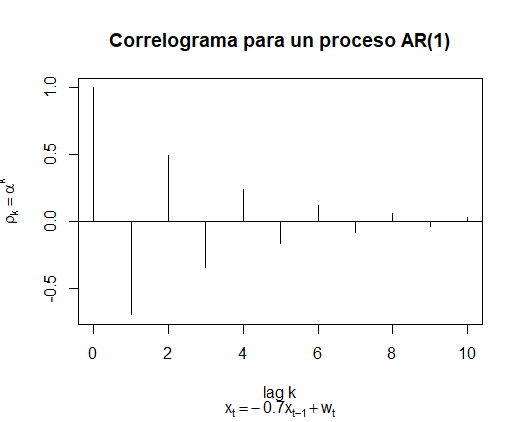

Imagen

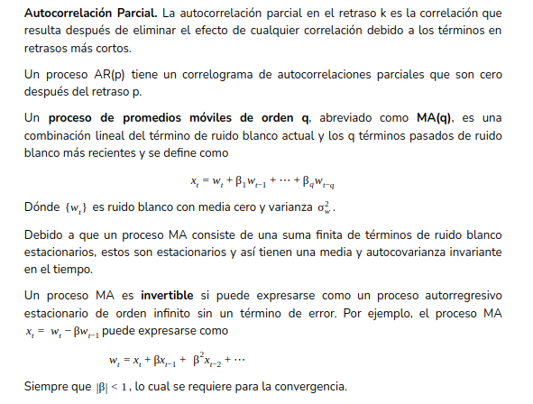

Imagen

## La función de autocovarianza sólo identifica un único proceso MA(q) si la condición de que el proceso sea invertible es impuesta.

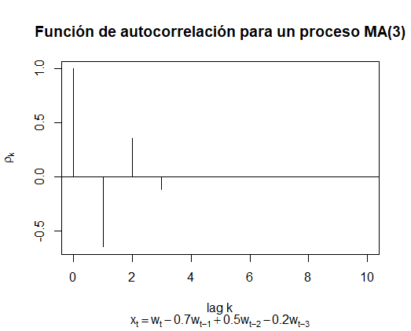

Imagen

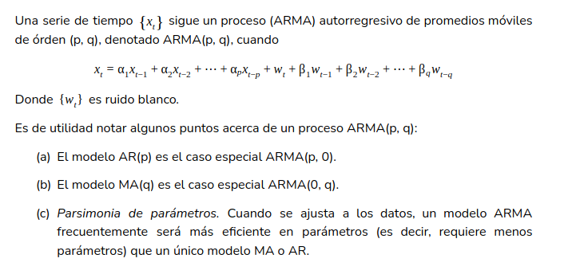

Imagen

## MODELOS NO ESTACIONARIOS Y PREDICCIÓN

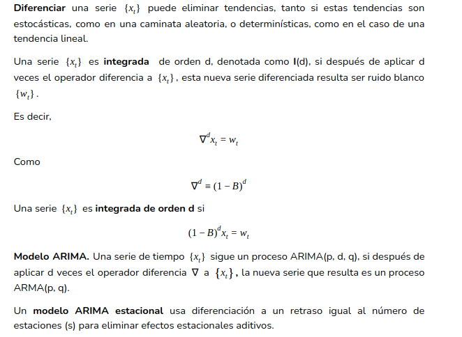

Imagen

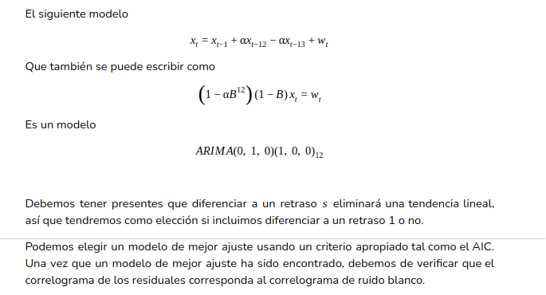

Imagen

# SESION 6. SERIES DE TIEMPO

## OBJETIVO

Obtener predicciones de ventas, de la demanda de productos o servicios, que ayuden a las organizaciones a ajustar presupuestos, justificar decisiones de marketing, o tener un mejor conocimiento sobre la evolución del negocio.

En esta sesión estudiaremos temas relacionados con los siguientes puntos:

- Datos que provienen de una variable que es medida secuencialmente en el tiempo durante o en un intervalo fijo (series de tiempo)
- Análisis de series de tiempo y ajustes de modelos para entender el pasado y predecir el futuro

# EJEMPLO1. Ejemplos de series de tiempo y técnicas descriptivas

## OBJETIVO

Entender el concepto de serie de tiempo y tomar consciencia sobre los problemas que podrían ayudar a resolver al analizarlas.

## DESARROLLO

En este ejemplo se hará la visualización y descomposición de series de tiempo, además de poder determinar la tendencia de nuestros datos a lo largo de un periodo de tiempo determinado, las series de tiempo son recolectadas y sirven para estudios de tipo retrospectivo, además también se pueden realizar predicciones a futuro. A continuación verás aplicaciones que te serán de mucha utilidad.

Técnicas descriptivas: gráficas, tendencias y variación estacional El primer dataset corresponde a las ventas mensuales de un filtro de aceite en diversos concesionarios para equipo de construcción.

library(TSA) data(oilfilters); plot(oilfilters, type = “o”, ylab = “Ventas”, xlab = “Tiempo”, main = “Ventas Mesuales”) plot(oilfilters, type = “l”, ylab = “Ventas”, xlab = “Tiempo”, main = “Ventas Mensuales de Filtro de Aceite”, sub = “Símbolos Especiales”) points(y = oilfilters, x = time(oilfilters), pch = as.vector(season(oilfilters))) Ahora utilizaremos el dataset AirPAssengers, el cual contiene datos de serie de tiempo correspondiente a pasajeros aéreos.

data(AirPassengers) AP <- AirPassengers AP Clase de un objeto

class(AP)

start(AP); end(AP); frequency(AP)

summary(AP)

plot(AP, ylab = “Pasajeros (1000’s)”, xlab = “Tiempo”, main = “Reserva de pasajeros aéreos internacionales”, sub = “Estados Unidos en el periodo 1949-1960”) layout(1:2) plot(aggregate(AP), xlab = “Tiempo”, main = “Reserva de pasajeros aéreos internacionales”, sub = “Estados Unidos en el periodo 1949-1960”)

boxplot(AP ~ cycle(AP), xlab = “Boxplot de valores estacionales”, sub = “Estados Unidos en el periodo 1949-1960”, main = “Reserva de pasajeros aéreos internacionales”) dev.off() Algunos datos en https://github.com/AtefOuni/ts/tree/master/Data

Series de Tiempo Múltiple Serie de producción de electricidad, cerveza y chocolate

CBE <- read.csv(“cbe.csv”, header = TRUE) CBE[1:4,] class(CBE)

Elec.ts <- ts(CBE[, 3], start = 1958, freq = 12) Beer.ts <- ts(CBE[, 2], start = 1958, freq = 12) Choc.ts <- ts(CBE[, 1], start = 1958, freq = 12)

Electricidad <- Elec.ts Cerveza <- Beer.ts Chocolate <- Choc.ts

plot(cbind(Electricidad, Cerveza, Chocolate), main = “Producción de Chocolate, Cerveza y Electricidad”, xlab = “Tiempo”, sub = “Enero de 1958 - Diciembre de 1990”) Serie de temperatura global

Global <- scan(“global.txt”) Global.ts <- ts(Global, st = c(1856, 1), end = c(2005, 12), fr = 12) Global.annual <- aggregate(Global.ts, FUN = mean) plot(Global.ts, xlab = “Tiempo”, ylab = “Temperatura en °C”, main = “Serie de Temperatura Global”, sub = “Serie mensual: Enero de 1856 a Diciembre de 2005”) plot(Global.annual, xlab = “Tiempo”, ylab = “Temperatura en °C”, main = “Serie de Temperatura Global”, sub = “Serie anual de temperaturas medias: 1856 a 2005”) New.series <- window(Global.ts, start = c(1970, 1), end = c(2005, 12)) New.time <- time(New.series) plot(New.series, xlab = “Tiempo”, ylab = “Temperatura en °C”, main = “Serie de Temperatura Global”, sub = “Serie mensual: Enero de 1970 a Diciembre de 2005”); abline(reg = lm(New.series ~ New.time)) Descomposición de series CBE <- read.csv(“cbe.csv”, header = TRUE) Elec.ts <- ts(CBE[, 3], start = 1958, freq = 12) Modelo Aditivo

Elec.decom.A <- decompose(Elec.ts)

plot(Elec.decom.A, xlab = “Tiempo”, sub = “Descomposición de los datos de producción de electricidad”) Componentes

Tendencia <- Elec.decom.A$trend Estacionalidad <- Elec.decom.A$seasonal Aleatorio <- Elec.decom.A$random

ts.plot(cbind(Tendencia, Tendencia + Estacionalidad), xlab = “Tiempo”, main = “Datos de Producción de Electricidad”, ylab = “Producción de electricidad”, lty = 1:2, sub = “Tendencia con efectos estacionales aditivos sobrepuestos”)

Tendencia[20] + Estacionalidad[20] + Aleatorio[20] Elec.ts[20] Modelo Multiplicativo

Elec.decom.M <- decompose(Elec.ts, type = “mult”)

plot(Elec.decom.M, xlab = “Tiempo”, sub = “Descomposición de los datos de producción de electricidad”) Componentes

Trend <- Elec.decom.M$trend Seasonal <- Elec.decom.M$seasonal Random <- Elec.decom.M$random

ts.plot(cbind(Trend, Trend*Seasonal), xlab = “Tiempo”, main = “Datos de Producción de Electricidad”, ylab = “Producción de electricidad”, lty = 1:2, sub = “Tendencia con efectos estacionales multiplicativos sobrepuestos”)

Trend[7]*Seasonal[7]*Random[7] Elec.ts[7]

Trend[100]*Seasonal[100]*Random[100] Elec.ts[100]

```r
#### Técnicas descriptivas: gráficas, tendencias y variación estacional

library(TSA)
```

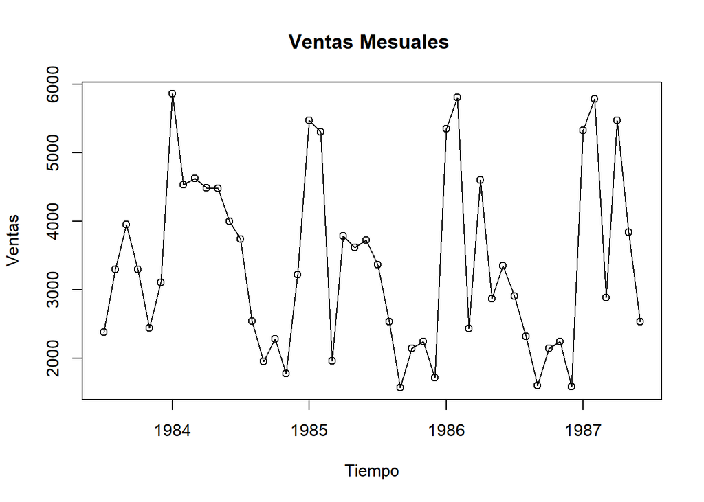

```r
data(oilfilters); plot(oilfilters, type = "o", ylab = "Ventas", xlab = "Tiempo", main = "Ventas Mesuales ")
```

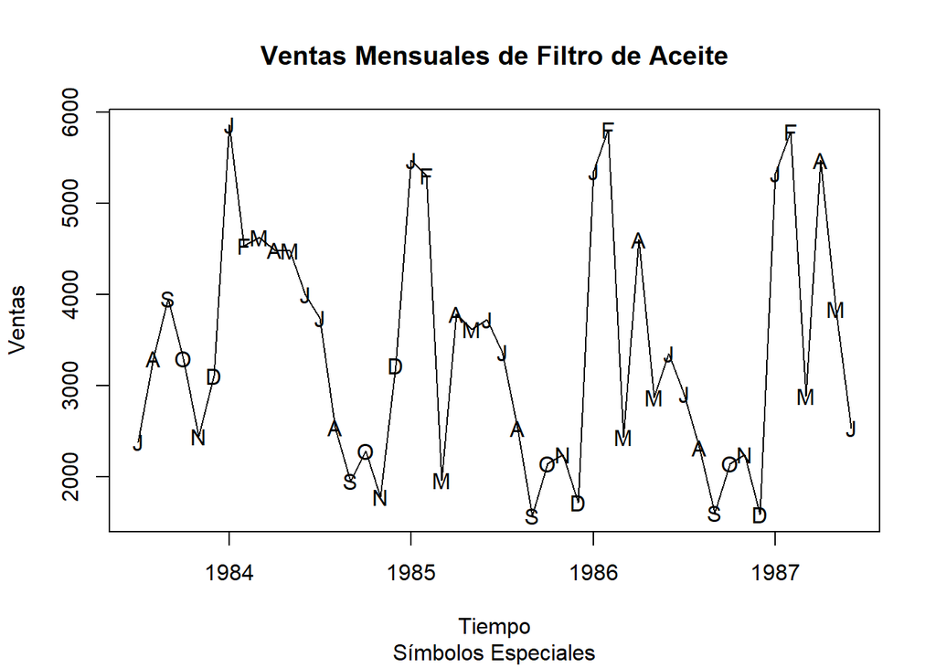

```r
plot(oilfilters, type = "l", ylab = "Ventas", xlab = "Tiempo",
                 main = "Ventas Mensuales de Filtro de Aceite",
                 sub = "Símbolos Especiales")
points(y = oilfilters, x = time(oilfilters),
pch = as.vector(season(oilfilters)))
```

```r
data(AirPassengers)
AP <- AirPassengers
AP
```

```
     Jan Feb Mar Apr May Jun Jul Aug Sep Oct Nov Dec
1949 112 118 132 129 121 135 148 148 136 119 104 118
1950 115 126 141 135 125 149 170 170 158 133 114 140
1951 145 150 178 163 172 178 199 199 184 162 146 166
1952 171 180 193 181 183 218 230 242 209 191 172 194
1953 196 196 236 235 229 243 264 272 237 211 180 201
1954 204 188 235 227 234 264 302 293 259 229 203 229
1955 242 233 267 269 270 315 364 347 312 274 237 278
1956 284 277 317 313 318 374 413 405 355 306 271 306
1957 315 301 356 348 355 422 465 467 404 347 305 336
1958 340 318 362 348 363 435 491 505 404 359 310 337
1959 360 342 406 396 420 472 548 559 463 407 362 405
1960 417 391 419 461 472 535 622 606 508 461 390 432
```

```r
# Clase de un objeto

class(AP)
```

```
[1] "ts"
```

```r
start(AP); end(AP); frequency(AP)
```

```
[1] 1949    1
```

```
[1] 1960   12
```

```
[1] 12
```

```r
summary(AP)
```

```
   Min. 1st Qu.  Median    Mean 3rd Qu.    Max.
  104.0   180.0   265.5   280.3   360.5   622.0
```

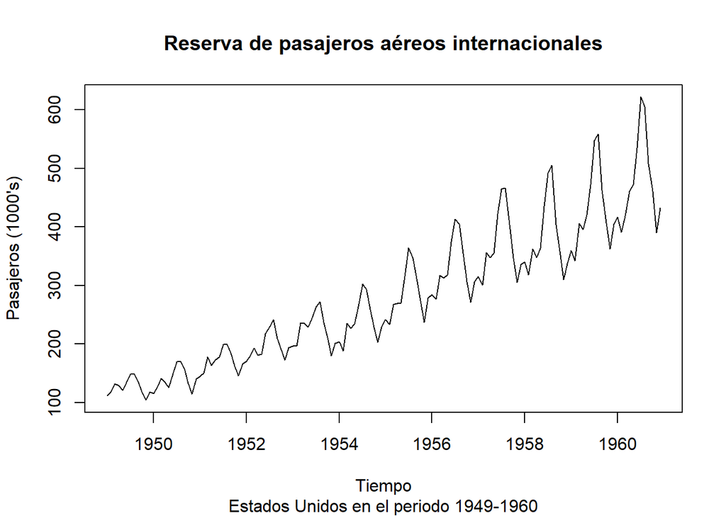

```r
plot(AP, ylab = "Pasajeros (1000's)", xlab = "Tiempo",
     main = "Reserva de pasajeros aéreos internacionales",
     sub = "Estados Unidos en el periodo 1949-1960")
```

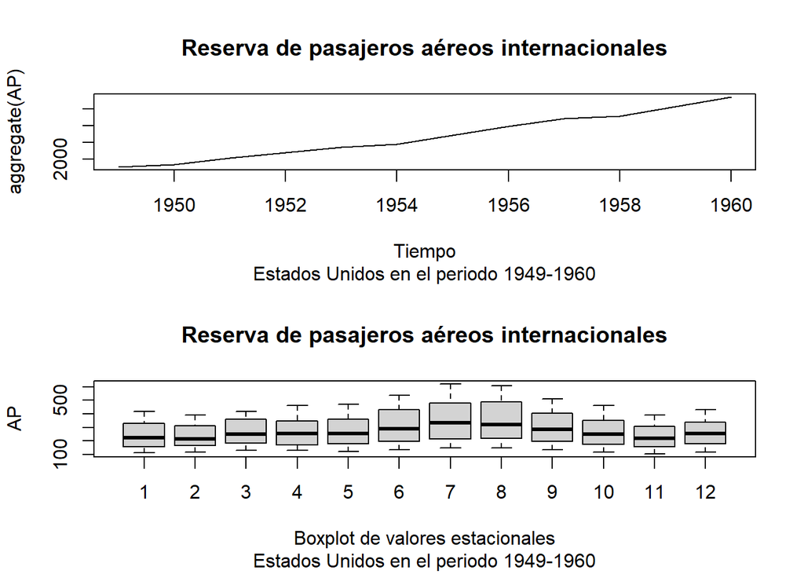

```r
################################################

layout(1:2)
plot(aggregate(AP), xlab = "Tiempo",
     main = "Reserva de pasajeros aéreos internacionales",
     sub = "Estados Unidos en el periodo 1949-1960")

boxplot(AP ~ cycle(AP),
        xlab = "Boxplot de valores estacionales",
        sub = "Estados Unidos en el periodo 1949-1960",
        main = "Reserva de pasajeros aéreos internacionales")
```

```r
dev.off()
```

```r
################################################

# https://github.com/AtefOuni/ts/tree/master/Data

# Series de Tiempo Múltiple

# Serie de producción de electricidad, cerveza y chocolate

CBE <- read.csv("cbe.csv", header = TRUE)
CBE[1:4,]
```

|  | choc | beer | elec |
| --- | --- | --- | --- |
| 1 | 1451 | 96.3 | 1497 |
| 2 | 2037 | 84.4 | 1463 |
| 3 | 2477 | 91.2 | 1648 |
| 4 | 2785 | 81.9 | 1595 |

```r
class(CBE)
```

```
[1] "data.frame"
```

```r
Elec.ts <- ts(CBE[, 3], start = 1958, freq = 12)
Beer.ts <- ts(CBE[, 2], start = 1958, freq = 12)
Choc.ts <- ts(CBE[, 1], start = 1958, freq = 12)

Electricidad <- Elec.ts
Cerveza <- Beer.ts
Chocolate <- Choc.ts

plot(cbind(Electricidad, Cerveza, Chocolate),
     main = "Producción de Chocolate, Cerveza y Electricidad",
     xlab = "Tiempo",
     sub = "Enero de 1958 - Diciembre de 1990")

################################################

# Serie de Temperatura Global

Global <- scan("global.txt")
Global.ts <- ts(Global, st = c(1856, 1), end = c(2005, 12), fr = 12)
Global.annual <- aggregate(Global.ts, FUN = mean)
plot(Global.ts, xlab = "Tiempo", ylab = "Temperatura en Â°C", main = "Serie de Temperatura Global",
     sub = "Serie mensual: Enero de 1856 a Diciembre de 2005")
plot(Global.annual, xlab = "Tiempo", ylab = "Temperatura en Â°C", main = "Serie de Temperatura Global",
     sub = "Serie anual de temperaturas medias: 1856 a 2005")

################################################

New.series <- window(Global.ts, start = c(1970, 1), end = c(2005, 12))
New.time <- time(New.series)
plot(New.series, xlab = "Tiempo", ylab = "Temperatura en Â°C", main = "Serie de Temperatura Global",
     sub = "Serie mensual: Enero de 1970 a Diciembre de 2005"); abline(reg = lm(New.series ~ New.time))


#### Descomposición de series

CBE <- read.csv("cbe.csv", header = TRUE)
Elec.ts <- ts(CBE[, 3], start = 1958, freq = 12)

# Modelo Aditivo

Elec.decom.A <- decompose(Elec.ts)

plot(Elec.decom.A, xlab = "Tiempo",
     sub = "Descomposición de los datos de producción de electricidad")

# Componentes

Tendencia <- Elec.decom.A$trend
Estacionalidad <- Elec.decom.A$seasonal
Aleatorio <- Elec.decom.A$random

ts.plot(cbind(Tendencia, Tendencia + Estacionalidad),
        xlab = "Tiempo", main = "Datos de Producción de Electricidad",
        ylab = "Producción de electricidad", lty = 1:2,
        sub = "Tendencia con efectos estacionales aditivos sobrepuestos")

Tendencia[20] + Estacionalidad[20] + Aleatorio[20]
```

[output not shown]

```
[1] 2016
```

```r
Elec.ts[20]
```

```
[1] 2016
```

```r
###

# Modelo Multiplicativo

Elec.decom.M <- decompose(Elec.ts, type = "mult")

plot(Elec.decom.M, xlab = "Tiempo",
     sub = "Descomposición de los datos de producción de electricidad")

# Componentes

Trend <- Elec.decom.M$trend
Seasonal <- Elec.decom.M$seasonal
Random <- Elec.decom.M$random

ts.plot(cbind(Trend, Trend*Seasonal), xlab = "Tiempo", main = "Datos de Producción de Electricidad",
        ylab = "Producción de electricidad", lty = 1:2,
        sub = "Tendencia con efectos estacionales multiplicativos sobrepuestos")

Trend[7]*Seasonal[7]*Random[7]
```

[output not shown]

```
[1] 1994
```

```r
Elec.ts[7]
```

```
[1] 1994
```

```r
Trend[100]*Seasonal[100]*Random[100]
```

```
[1] 3033
```

```r
Elec.ts[100]
```

```
[1] 3033
```

```r
# J. Cryer & K. Chan. (2008). Time Series Analysis With Applications
# in R. 233 Spring Street, New York, NY 10013, USA: Springer
# Science+Business Media, LLC.

# P. Cowpertwait & A. Metcalfe. (2009). Introductory Time Series with R.
# 233 Spring Street, New York, NY 10013, USA: Springer Science+Business
# Media, LLC.
```

# EJEMPLO 2. Modelos estocásticos básicos, modelos estacionarios y predicción

## OBJETIVO

Estudiar algunos modelos estocásticos básicos, modelos estacionarios y realizar predicciones de algunas series de tiempo.

## DESARROLLO

En el desarrollo de este ejemplo se van a tratar tópicos como: ruido blanco, caminatas aleatorias, operadores de rezago y diferencia.

Ruido Blanco y simulación en R

set.seed(1) w <- rnorm(100) plot(w, type = “l”, xlab = "“) title(main =”Ruido Blanco Gaussiano“, xlab =”Tiempo") Para ilustrar mediante simulación como las muestras pueden diferir de sus poblaciones subyacentes considere lo siguiente

x <- seq(-3, 3, length = 1000) hist(rnorm(100), prob = T, ylab = "“, xlab =”“, main =”“) points(x, dnorm(x), type =”l“) title(ylab =”Densidad“, xlab =”Valores simulados de la distribución normal estandar“, main =”Comparación de una muestra con su población subyacente“) set.seed(2) acf(rnorm(100), main =”“) title(main =”Función de Autocorrelación Muestral“, sub =”Valores simulados de la distribución normal estandar") Caminata aleatoria y simulación en R

x <- w <- rnorm(1000) for(t in 2:1000) x[t] <- x[t-1] + w[t] plot(x, type = “l”, main = “Caminata Aleatoria Simulada”, xlab = “t”, ylab = expression(x[t]), sub = expression(x[t]==x[t-1]+w[t])) acf(x, main = "“) title(main =”Correlograma para la caminata aleatoria simulada", sub = expression(x[t]==x[t-1]+w[t])) Modelos ajustados y gráficas de diágnostico, series de caminatas aleatorias simuladas. El correlograma de las series de diferencias puede usarse para evaluar si una serie dada puede modelarse como una caminata aleatoria

acf(diff(x), main = "“) title(main =”Correlograma de la serie de diferencias", sub = expression(nabla*x[t]==x[t]-x[t-1])) Modelos AR(p), MA(q) y ARMA(p, q) Modelos AR(p)

Correlograma de un proceso AR(1)

rho <- function(k, alpha) alpha^k plot(0:10, rho(0:10, 0.7), type = “h”, ylab = "“, xlab =”“) title(main =”Correlograma para un proceso AR(1)“, ylab = expression(rho[k] == alpha^k), xlab =”lag k", sub = expression(x[t]==0.7*x[t-1]+w[t]))

plot(0:10, rho(0:10, -0.7), type = “h”, ylab = "“, xlab =”“) title(main =”Correlograma para un proceso AR(1)“, ylab = expression(rho[k] == alpha^k), xlab =”lag k", sub = expression(x[t]==-0.7*x[t-1]+w[t])) abline(h = 0) Simulación en R

Un proceso AR(1) puede ser simulado en R como sigue:

set.seed(1) x <- w <- rnorm(100) for(t in 2:100) x[t] <- 0.7 * x[t-1] + w[t] plot(x, type = “l”, xlab = "“, ylab =”“) title(main =”Proceso AR(1) simulado“, xlab =”Tiempo“, ylab = expression(x[t]), sub = expression(x[t]==0.7*x[t-1]+w[t])) acf(x, main = "") title(main = "Correlograma del proceso AR(1) simulado", sub = expression(x[t]==0.7*x[t-1]+w[t])) pacf(x, main =”“) title(main =”Correlograma Parcial del proceso AR(1) simulado", sub = expression(x[t]==0.7*x[t-1]+w[t])) Modelos Ajustados

Ajuste de modelos a series simuladas

x.ar <- ar(x, method = “mle”) x.ar$order x.ar$ar x.ar$ar + c(-2, 2)*sqrt(x.ar$asy.var) Serie de temperatura global: Ajuste de un modelo AR

Global <- scan(“global.txt”) Global.ts <- ts(Global, st = c(1856, 1), end = c(2005, 12), fr = 12) Global.annual <- aggregate(Global.ts, FUN = mean) plot(Global.ts, xlab = “Tiempo”, ylab = “Temperatura en °C”, main = “Serie de Temperatura Global”, sub = “Serie mensual: Enero de 1856 a Diciembre de 2005”) plot(Global.annual, xlab = “Tiempo”, ylab = “Temperatura en °C”, main = “Serie de Temperatura Global”, sub = “Serie anual de temperaturas medias: 1856 a 2005”) mean(Global.annual) Global.ar <- ar(Global.annual, method = “mle”) Global.ar$order Global.ar$ar acf(Global.ar$res[-(1:Global.ar$order)], lag = 50, main = "“) title(main =”Correlograma de la serie de residuales“, sub =”Modelo AR(4) ajustado a la serie de temperaturas globales anuales") Modelos MA(q)

Ejemplos en R: Correlograma y Simulación

Función en R para calcular la Función de Autocorrelación

rho <- function(k, beta){ q <- length(beta) - 1 if(k > q) ACF <- 0 else { s1 <- 0; s2 <- 0 for(i in 1:(q-k+1)) s1 <- s1 + beta[i]*beta[i + k] for(i in 1:(q+1)) s2 <- s2 + beta[i]^2 ACF <- s1/s2} ACF} Correlograma para un proceso MA(3)

beta <- c(1, 0.7, 0.5, 0.2) rho.k <- rep(1, 10) for(k in 1:10) rho.k[k] <- rho(k, beta) plot(0:10, c(1, rho.k), ylab = expression(rho[k]), xlab = “lag k”, type = “h”, sub = expression(x[t] == w[t] + 0.7*w[t-1] + 0.5*w[t-2] + 0.2*w[t-3]), main = “Función de autocorrelación para un proceso MA(3)”) abline(0, 0) Correlograma para otro proceso MA(3)

beta <- c(1, -0.7, 0.5, -0.2) rho.k <- rep(1, 10) for(k in 1:10) rho.k[k] <- rho(k, beta) plot(0:10, c(1, rho.k), ylab = expression(rho[k]), xlab = “lag k”, type = “h”, sub = expression(x[t] == w[t] - 0.7*w[t-1] + 0.5*w[t-2] - 0.2*w[t-3]), main = “Función de autocorrelación para un proceso MA(3)”) abline(0, 0) Simulación de un proceso MA(3)

set.seed(1) b <- c(0.8, 0.6, 0.4) x <- w <- rnorm(1000) for(t in 4:1000){ for(j in 1:3) x[t] <- x[t] + b[j]*w[t-j] }

plot(x, type = “l”, ylab = expression(x[t]), xlab = “Tiempo t”, sub = expression(x[t] == w[t] + 0.8*w[t-1] + 0.6*w[t-2] + 0.4*w[t-3]), main = “Serie de tiempo simulada de un proceso MA(3)”) acf(x, main = "“) title(main =”Correlograma para un proceso MA(3) simulado", sub = expression(x[t] == w[t] + 0.8*w[t-1] + 0.6*w[t-2] + 0.4*w[t-3])) Ajuste de modelos MA

x.ma <- arima(x, order = c(0, 0, 3)) x.ma Modelos ARMA(p, q)

Simulación y ajuste

set.seed(1) x <- arima.sim(n = 10000, list(ar = -0.6, ma = 0.5)) plot(x[1:100], type = “l”, xlab = "“) title(main =”Serie simulada“, xlab =”Tiempo", sub = expression(x[t] == -0.6*x[t-1] + w[t] + 0.5*w[t-1])) coef(arima(x, order = c(1, 0, 1))) Predicción Serie de producción de electricidad

CBE <- read.csv(“cbe.csv”, header = TRUE) Elec.ts <- ts(CBE[, 3], start = 1958, freq = 12) plot(Elec.ts, xlab = "“, ylab =”“) title(main =”Serie de Producción de Electricidad“, xlab =”Tiempo“, ylab =”Producción de electricidad“) plot(log(Elec.ts), xlab =”“, ylab =”“) title(main =”Serie-log de Producción de Electricidad“, xlab =”Tiempo“, ylab =”Log de Producción de electricidad“) Time <- 1:length(Elec.ts) Imth <- cycle(Elec.ts) Elec.lm <- lm(log(Elec.ts) ~ Time + I(Time^2) + factor(Imth)) acf(resid(Elec.lm), main =”“) title(main =”Correlograma de la serie de residuales del modelo de regresión“, sub =”Serie de producción de electricidad“) plot(resid(Elec.lm), type =”l“, main =”“, xlab =”“, ylab =”“) title(main =”Serie de residuales del modelo de regresión ajustado“, sub =”Serie de producción de electricidad“, xlab =”Tiempo“, ylab =”Residuales") Código para encontrar el mejor modelo ARMA(p, q) considerando el AIC (Akaike Information Criterion)

best.order <- c(0, 0, 0) best.aic <- Inf for(i in 0:2)for(j in 0:2){ model <- arima(resid(Elec.lm), order = c(i, 0, j)) fit.aic <- AIC(model) if(fit.aic < best.aic){ best.order <- c(i, 0, j) best.arma <- arima(resid(Elec.lm), order = best.order) best.aic <- fit.aic } }

best.order acf(resid(best.arma), main = "“) title(main =”Serie de residuales del modelo ARMA(2, 0) ajustado“, sub =”Serie de residuales del modelo de regresión ajustado a los datos de electricidad“) new.time <- seq(length(Elec.ts)+1, length = 36) new.data <- data.frame(Time = new.time, Imth = rep(1:12, 3)) predict.lm <- predict(Elec.lm, new.data) predict.arma <- predict(best.arma, n.ahead = 36) elec.pred <- ts(exp(predict.lm + predict.arma$pred), start = 1991, freq = 12) ts.plot(cbind(Elec.ts, elec.pred), lty = 1:2, col = c(”blue“,”red“), xlab =”Tiempo“, ylab =”Producción de electricidad“, main =”Predicción de los datos de producción de electricidad“, sub =”Predicción de 36 meses")

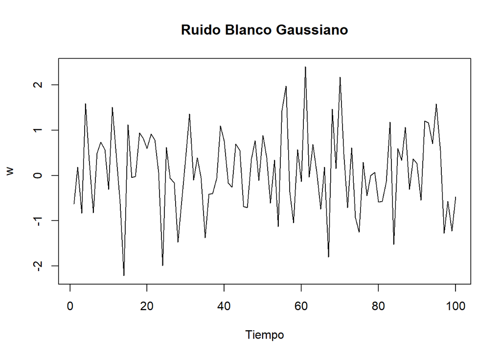

```r
# Ejemplo 2. Modelos estocásticos básicos, modelos estacionarios y predicción

# Ruido Blanco y simulación en R

set.seed(1)
w <- rnorm(100)
plot(w, type = "l", xlab = "")
title(main = "Ruido Blanco Gaussiano", xlab = "Tiempo")
```

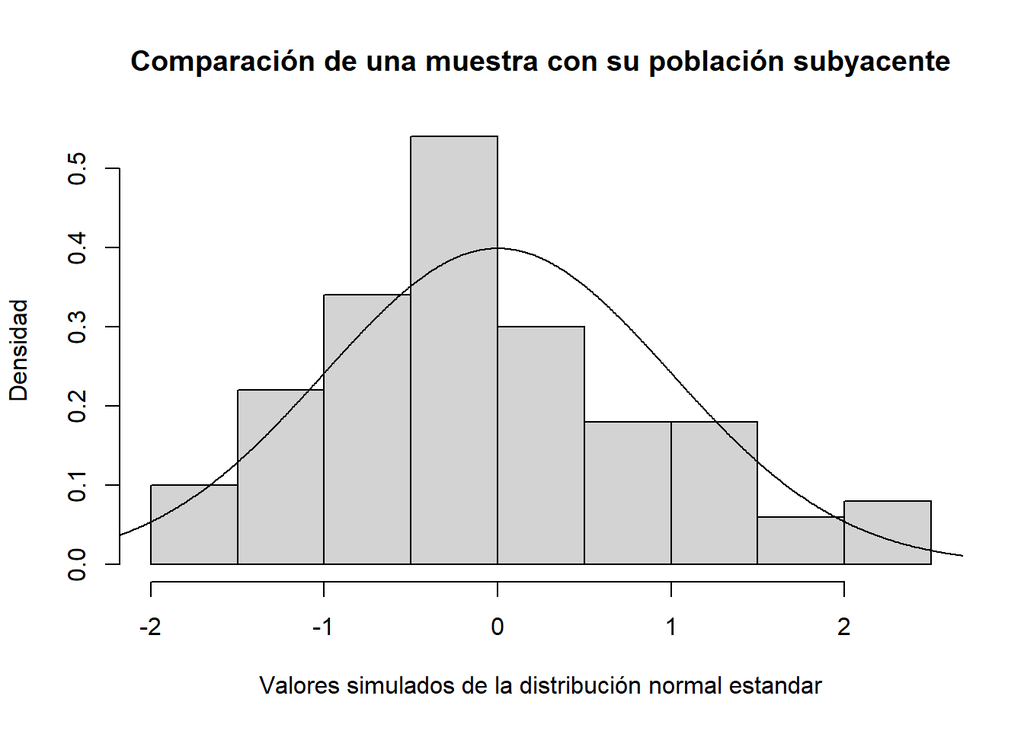

```r
###

# Para ilustrar mediante simulación como las muestras pueden diferir
# de sus poblaciones subyacentes considere lo siguiente

x <- seq(-3, 3, length = 1000)
hist(rnorm(100), prob = T, ylab = "", xlab = "", main = "")
points(x, dnorm(x), type = "l")
title(ylab = "Densidad", xlab = "Valores simulados de la distribución normal estandar",
      main = "Comparación de una muestra con su población subyacente")
```

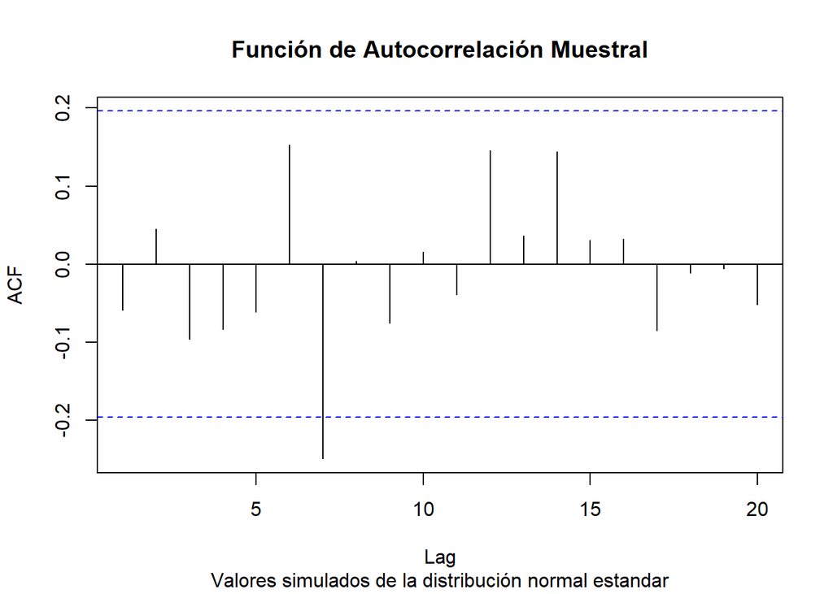

```r
###

set.seed(2)
acf(rnorm(100), main = "")
title(main = "Función de Autocorrelación Muestral",
      sub = "Valores simulados de la distribución normal estandar")
```

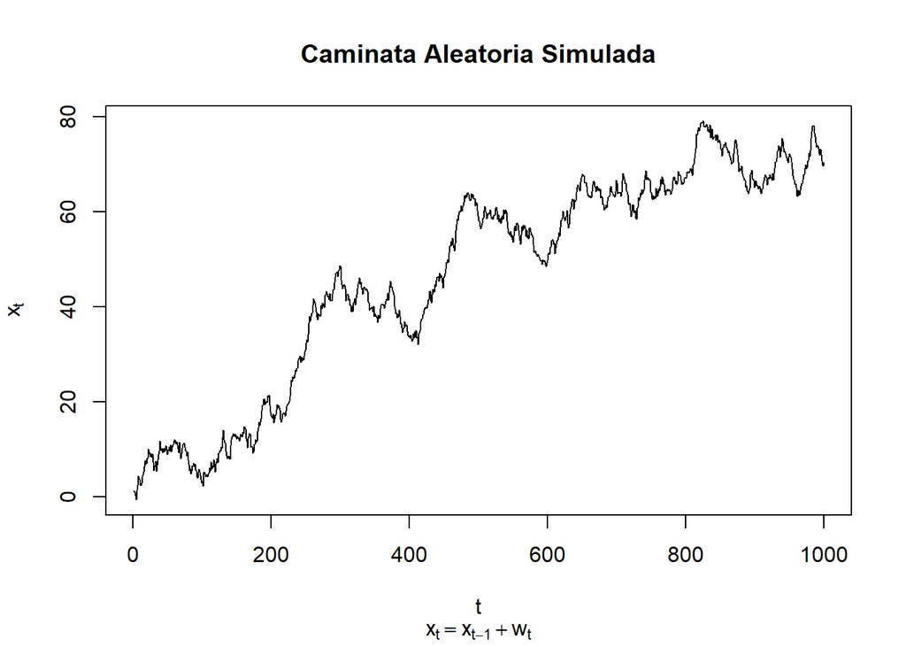

```r
###

              # Caminata Aleatoria
              # Simulación en R

x <- w <- rnorm(1000)
for(t in 2:1000) x[t] <- x[t-1] + w[t]
plot(x, type = "l", main = "Caminata Aleatoria Simulada",
     xlab = "t", ylab = expression(x[t]),
     sub = expression(x[t]==x[t-1]+w[t]))
```

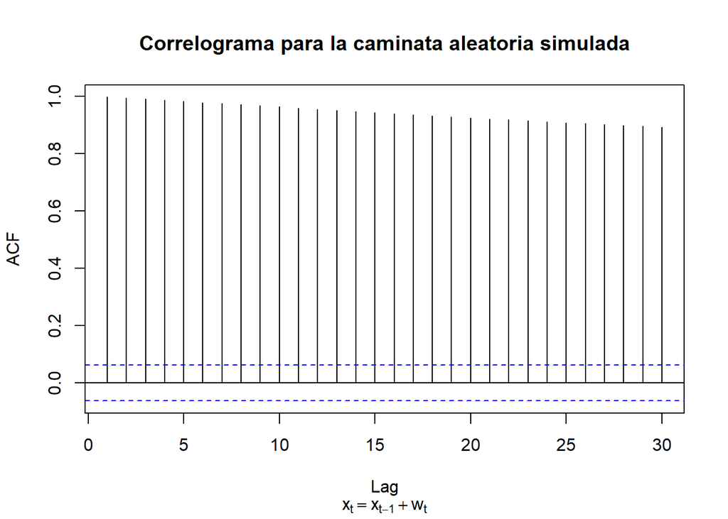

```r
acf(x, main = "")
title(main = "Correlograma para la caminata aleatoria simulada",
      sub = expression(x[t]==x[t-1]+w[t]))
```

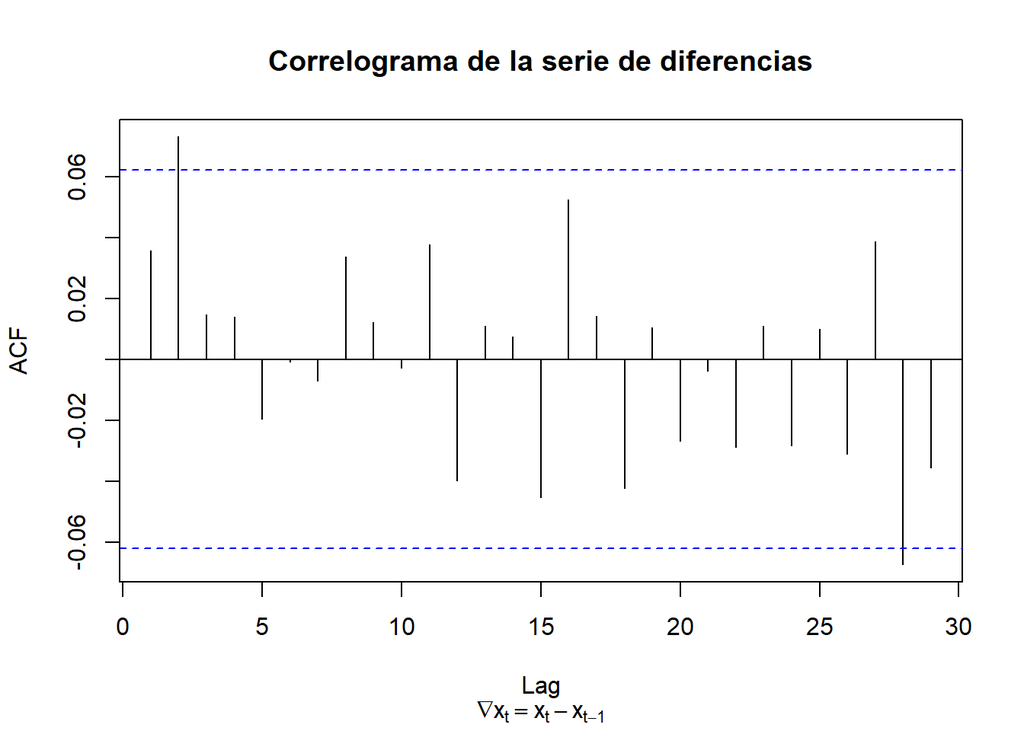

```r
###

        # Modelos Ajustados y gráficas de diagnóstico
      # Series de caminatas aleatorias simuladas

# El correlograma de las series de diferencias puede usarse para evaluar si una serie dada
# puede modelarse como una caminata aleatoria

acf(diff(x), main = "")
title(main = "Correlograma de la serie de diferencias",
      sub = expression(nabla*x[t]==x[t]-x[t-1]))
```

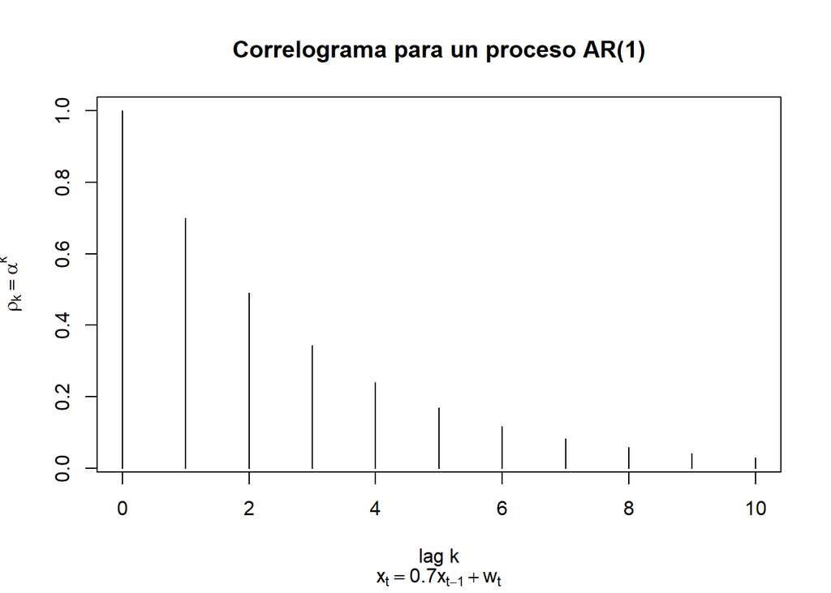

```r
#### Modelos AR(p), MA(q) y ARMA(p, q)

# Modelos AR(p)

# Correlograma de un proceso AR(1)

rho <- function(k, alpha) alpha^k
plot(0:10, rho(0:10, 0.7), type = "h", ylab = "", xlab = "")
title(main = "Correlograma para un proceso AR(1)",
      ylab = expression(rho[k] == alpha^k),
      xlab = "lag k",
      sub = expression(x[t]==0.7*x[t-1]+w[t]))
```

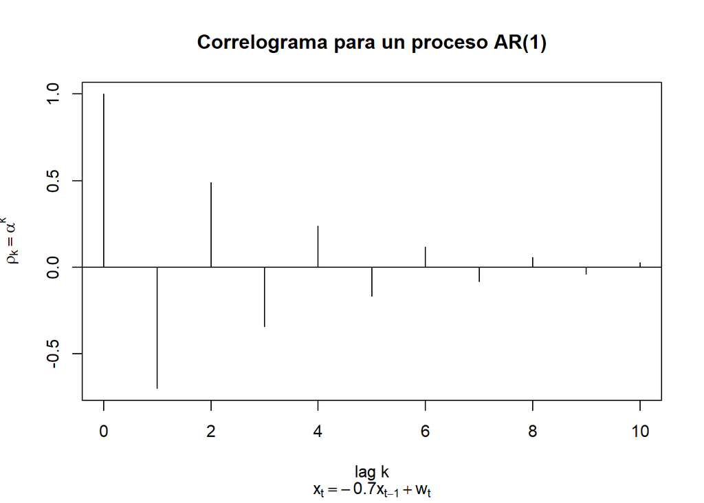

```r
plot(0:10, rho(0:10, -0.7), type = "h", ylab = "", xlab = "")
title(main = "Correlograma para un proceso AR(1)",
      ylab = expression(rho[k] == alpha^k),
      xlab = "lag k",
      sub = expression(x[t]==-0.7*x[t-1]+w[t]))
abline(h = 0)
```

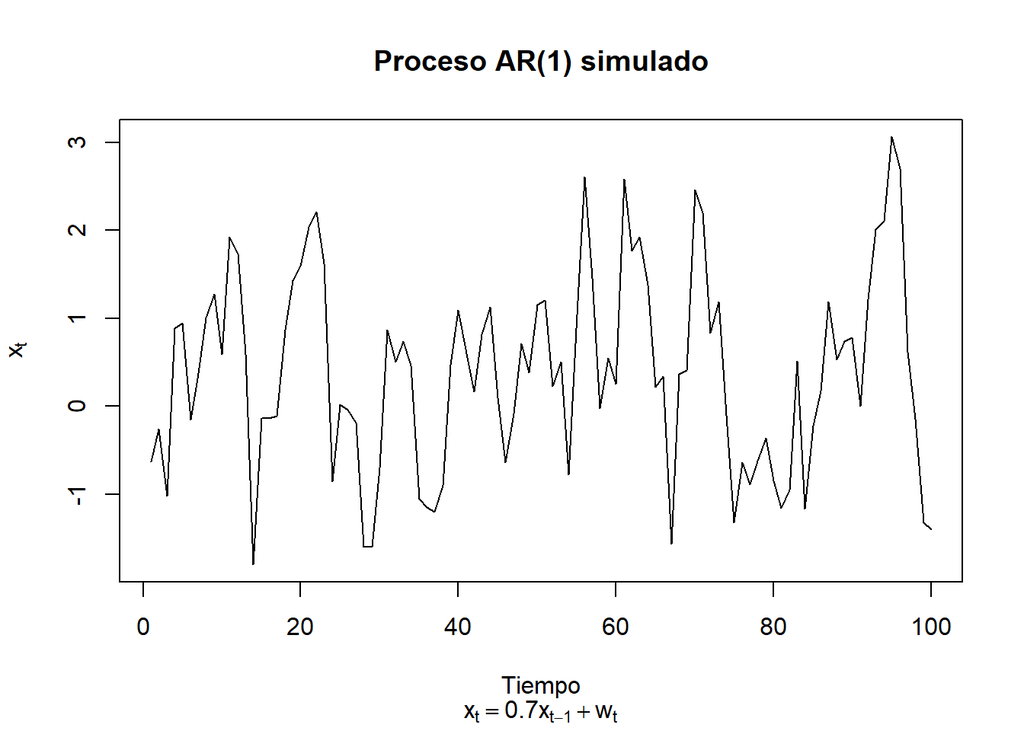

```r
###

# Simulación en R

# Un proceso AR(1) puede ser simulado en R como sigue:

set.seed(1)
x <- w <- rnorm(100)
for(t in 2:100) x[t] <- 0.7 * x[t-1] + w[t]
plot(x, type = "l", xlab = "", ylab = "")
title(main = "Proceso AR(1) simulado",
      xlab = "Tiempo",
      ylab = expression(x[t]),
      sub = expression(x[t]==0.7*x[t-1]+w[t]))
```

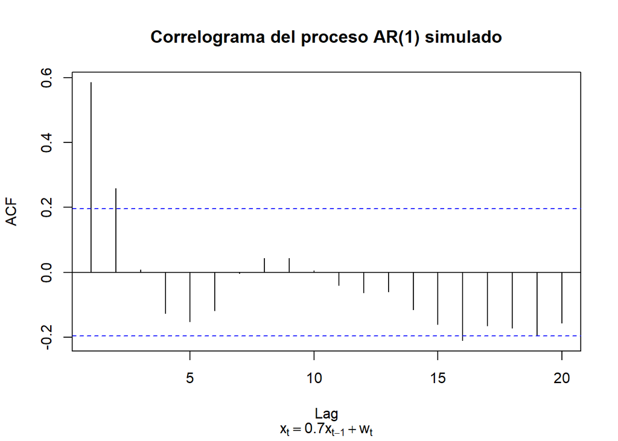

```r
#

acf(x, main = "")
title(main = "Correlograma del proceso AR(1) simulado",
      sub = expression(x[t]==0.7*x[t-1]+w[t]))
```

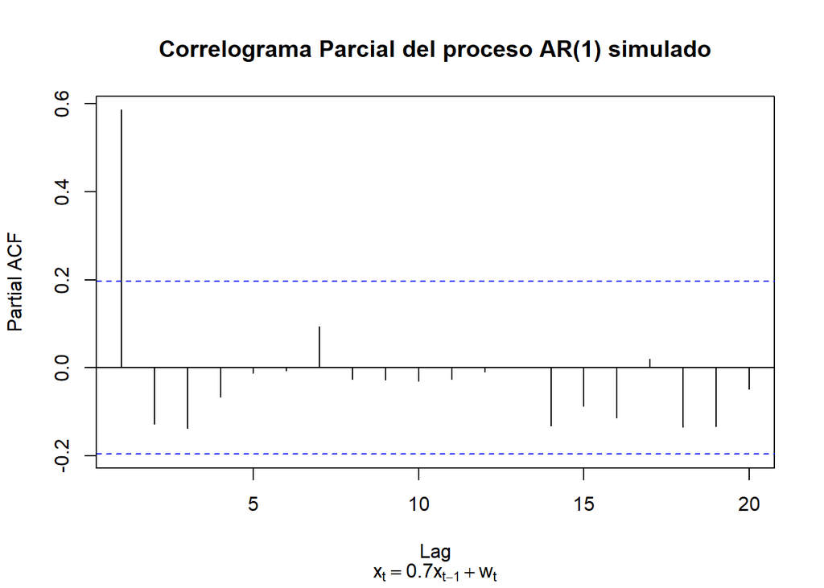

```r
#

pacf(x, main = "")
title(main = "Correlograma Parcial del proceso AR(1) simulado",
      sub = expression(x[t]==0.7*x[t-1]+w[t]))
```

```r
###

# Modelos Ajustados

# Ajuste de modelos a series simuladas

x.ar <- ar(x, method = "mle")
x.ar$order
```

```
[1] 1
```

```r
x.ar$ar
```

```
[1] 0.6009459
```

```r
x.ar$ar + c(-2, 2)*sqrt(x.ar$asy.var)
```

```
[1] 0.4404031 0.7614886
```

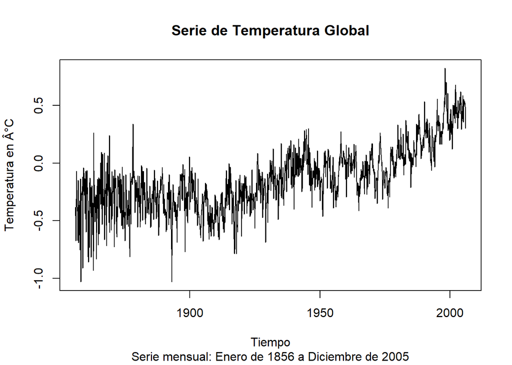

```r
# Serie de temperatura global: Ajuste de un modelo AR

Global <- scan("global.txt")
Global.ts <- ts(Global, st = c(1856, 1), end = c(2005, 12), fr = 12)
Global.annual <- aggregate(Global.ts, FUN = mean)
plot(Global.ts, xlab = "Tiempo", ylab = "Temperatura en Â°C",
     main = "Serie de Temperatura Global",
     sub = "Serie mensual: Enero de 1856 a Diciembre de 2005")
```

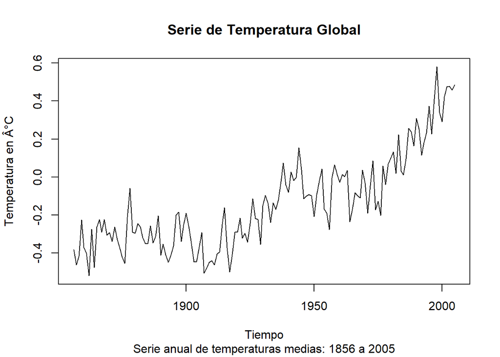

```r
plot(Global.annual, xlab = "Tiempo", ylab = "Temperatura en Â°C",
     main = "Serie de Temperatura Global",
     sub = "Serie anual de temperaturas medias: 1856 a 2005")
```

```r
#

mean(Global.annual)
```

```
[1] -0.1382628
```

```r
Global.ar <- ar(Global.annual, method = "mle")
Global.ar$order
```

```
[1] 4
```

```r
Global.ar$ar
```

```
[1] 0.58762026 0.01260254 0.11116731 0.26763656
```